# Predicting Human Activity

Mark Potter

December 26, 2016

# Executive Summary

This project will show how a model is developed to predict how well a human activity is performed based on a dataset developed by Velloso, E.; Bulling, A.; Gellersen, H.; Ugulino, W.; Fuks, H. Qualitative Activity Recognition of Weight Lifting Exercises. Proceedings of 4th International Conference in Cooperation with SIGCHI (Augmented Human ’13) . Stuttgart, Germany: ACM SIGCHI, 2013.

Results are published: [Predicting Human Activity](http://rpubs.com/mpotter54/PredictingHumanActivity)

## Explore and Clean the Data

```r
        # load data
        mainDir <- "C:/PracticalMachineLearningClassProject"
        setwd(mainDir)
        fileTraining <- "pml-training.csv"
        training <- read.csv(file=fileTraining, head=TRUE, sep=",",
                             na.strings=c('#DIV/0', '', 'NA'),
                             stringsAsFactors = FALSE)
        fileTesting <- "pml-testing.csv"
        testing <- read.csv(file=fileTesting, head=TRUE, sep=",",
                             na.strings=c('#DIV/0', '', 'NA'),
                             stringsAsFactors = FALSE)
        # clean data
        drops <- colnames(training)[colSums(is.na(training)) > 19000]
        drops <- c("X", "user_name", "cvtd_timestamp", "raw_timestamp_part_1", "raw_timestamp_part_2",
                   "new_window", "num_window", drops)
        train2 <- training[, !(names(training) %in% drops)]
        tsFN <- testing[, !(names(training) %in% drops)]
        inTrain <- createDataPartition(train2$classe,p=0.7,list=FALSE)
        trFN <- train2[inTrain,]
        vaFN <- train2[-inTrain,]
        trFN$classe <- as.factor(trFN$classe)
        vaFN$classe <- as.factor(vaFN$classe)
```

### Dimensions

The training dataset has 19622 rows and 160 columns. The testing has dataset has 20 rows and 160 columns. We will split the training set into a training and validation set using a .7 split.

### Clean the Data

Several of the columns contain mostly NA’s and #DIV/0! these columns are removed before the model is developed. In addition, columns row number, user name, cvtd_timestamp, raw_timestamp_part_1, raw_timestamp_part_2, new_window, and num_window columns are not used in the analysis. The columns removed are shown in table 1. After column removal the training, validation and testing datsets have 53 columns.

### Attribute types

The attributes of the final columns are included in table 2 in the appendix. We will be developing a model to predict classe from the other columns in the dataset. The levels of classe are shown in table 3.

## Experiment with models

For Train controlling we will use cross validation (cv) with a number of 10. Our metric will be accuracy. Due to time to evaluate the model we will use an n sample size of 1200 to do the experiment with.

```r
n <- 1200
sample <- sample_n(trFN, n)
tc <- trainControl(method="cv", number=10)
mc <- "Accuracy"
# LDA
set.seed(n)
model.lda <- train(classe~., data=sample, method="lda", metric=mc, trControl=tc)
# CART
set.seed(n)
model.cart <- train(classe~., data=sample, method="rpart", metric=mc, trControl=tc)
# KNN
set.seed(n)
model.knn <- train(classe~., data=sample, method="knn", metric=mc, trControl=tc)
# SVM
set.seed(n)
model.svm <- train(classe~., data=sample, method="svmRadial", metric=mc, trControl=tc)
# Random Forest
set.seed(n)
model.rf <- train(classe~., data=sample, method="rf", metric=mc, trControl=tc)
# Naive Bayes
set.seed(n)
model.nb <- train(classe~., data=sample, method="nb", metric=mc, trControl=tc)
# Gradient Boosting
set.seed(n)
model.gbm <- train(classe~., data=sample, method="gbm", metric=mc, trControl=tc, verbose=FALSE)
# Select the best model
results <- resamples(list(lda=model.lda,
                          cart=model.cart,
                          knn=model.knn,
                          svm=model.svm,
                          rf=model.rf,
                          nb=model.nb,
                          gbm=model.gbm))
summary(results)
```

```
##
## Call:
## summary.resamples(object = results)
##
## Models: lda, cart, knn, svm, rf, nb, gbm
## Number of resamples: 10
##
## Accuracy
##        Min. 1st Qu. Median   Mean 3rd Qu.   Max. NA's
## lda  0.6333  0.6757 0.6916 0.6900  0.7083 0.7333    0
## cart 0.5000  0.5146 0.5270 0.5400  0.5667 0.5917    0
## knn  0.5702  0.5996 0.6250 0.6208  0.6396 0.6583    0
## svm  0.6917  0.7167 0.7250 0.7275  0.7350 0.7647    0
## rf   0.8583  0.9048 0.9167 0.9142  0.9234 0.9583    0
## nb   0.5714  0.6104 0.6597 0.6424  0.6749 0.6891    0
## gbm  0.8678  0.8854 0.8963 0.9059  0.9354 0.9496    0
##
## Kappa
##        Min. 1st Qu. Median   Mean 3rd Qu.   Max. NA's
## lda  0.5393  0.5876 0.6084 0.6075  0.6315 0.6642    0
## cart 0.3609  0.3846 0.4009 0.4162  0.4447 0.4883    0
## knn  0.4601  0.4926 0.5252 0.5201  0.5446 0.5677    0
## svm  0.6092  0.6410 0.6500 0.6540  0.6648 0.7010    0
## rf   0.8201  0.8797 0.8945 0.8913  0.9033 0.9473    0
## nb   0.4623  0.5088 0.5715 0.5500  0.5911 0.6072    0
## gbm  0.8335  0.8548 0.8688 0.8810  0.9184 0.9362    0
```

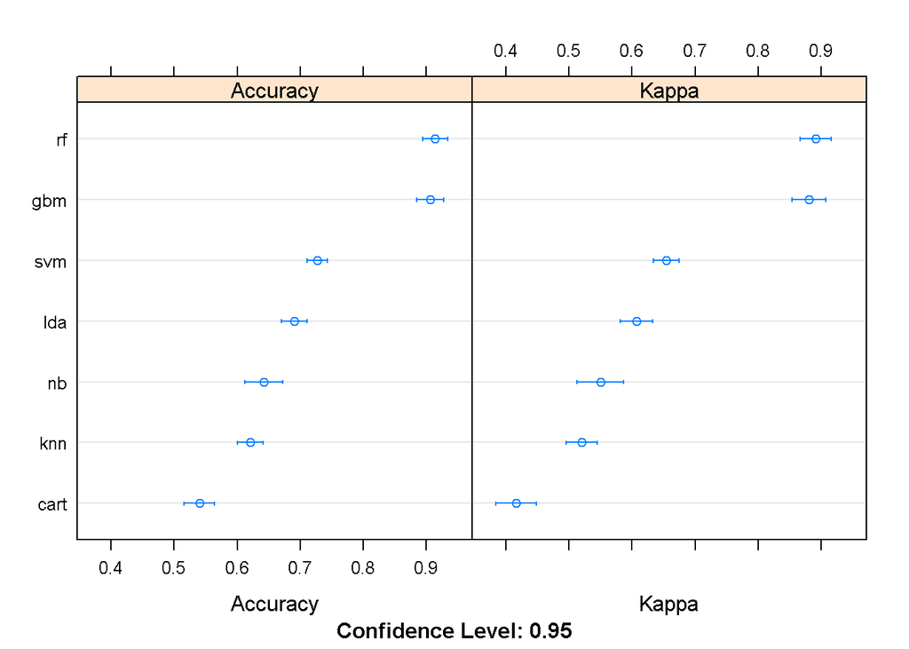

```r
dotplot(results)
```

## Select model

Random Forest and Gradient Boosting are the best models. Lets fully train them. We pick the random forest model based on accuracy.

```r
# Random Forest
n <- 2400
set.seed(n)
model2.rf <- train(classe~., data=trFN, method="rf", metric=mc, trControl=tc)
# Gradient Boosting
set.seed(n)
model2.gbm <- train(classe~., data=trFN, method="gbm", metric=mc, trControl=tc, verbose=FALSE)
# Select the best model
results2 <- resamples(list(rf=model2.rf, gbm=model2.gbm))
summary(results2)
```

```
##
## Call:
## summary.resamples(object = results2)
##
## Models: rf, gbm
## Number of resamples: 10
##
## Accuracy
##       Min. 1st Qu. Median   Mean 3rd Qu.   Max. NA's
## rf  0.9876  0.9900  0.992 0.9918  0.9938 0.9956    0
## gbm 0.9498  0.9554  0.961 0.9597  0.9642 0.9672    0
##
## Kappa
##       Min. 1st Qu. Median   Mean 3rd Qu.   Max. NA's
## rf  0.9843  0.9873 0.9899 0.9896  0.9922 0.9945    0
## gbm 0.9365  0.9436 0.9507 0.9491  0.9547 0.9585    0
```

## Test model

Test the random forest model against the validation set.

```r
# Random Forest
pred.rf <- predict(model2.rf, newdata = vaFN)
cm <- confusionMatrix(pred.rf, vaFN$classe)
print(cm)
```

```
## Confusion Matrix and Statistics
##
##           Reference
## Prediction    A    B    C    D    E
##          A 1674    7    0    0    0
##          B    0 1130    9    0    0
##          C    0    2 1016   15    0
##          D    0    0    1  949    4
##          E    0    0    0    0 1078
##
## Overall Statistics
##
##                Accuracy : 0.9935
##                  95% CI : (0.9911, 0.9954)
##     No Information Rate : 0.2845
##     P-Value [Acc > NIR] : < 2.2e-16
##
##                   Kappa : 0.9918
##  Mcnemar's Test P-Value : NA
##
## Statistics by Class:
##
##                      Class: A Class: B Class: C Class: D Class: E
## Sensitivity            1.0000   0.9921   0.9903   0.9844   0.9963
## Specificity            0.9983   0.9981   0.9965   0.9990   1.0000
## Pos Pred Value         0.9958   0.9921   0.9835   0.9948   1.0000
## Neg Pred Value         1.0000   0.9981   0.9979   0.9970   0.9992
## Prevalence             0.2845   0.1935   0.1743   0.1638   0.1839
## Detection Rate         0.2845   0.1920   0.1726   0.1613   0.1832
## Detection Prevalence   0.2856   0.1935   0.1755   0.1621   0.1832
## Balanced Accuracy      0.9992   0.9951   0.9934   0.9917   0.9982
```

The expected accuracy percentage is 99.35 . The out of sample error rate is expected percentage is 0.65 .

## Perform final model test

Test the random forest model against the test set.

```r
# Random Forest
pred.rft <- predict(model2.rf, newdata = tsFN)
print(pred.rft)
```

```
##  [1] B A B A A E D B A A B C B A E E A B B B
## Levels: A B C D E
```

# Appendix

## Table 1 Columns Removed

```
##   [1] "X"                        "user_name"
##   [3] "cvtd_timestamp"           "raw_timestamp_part_1"
##   [5] "raw_timestamp_part_2"     "new_window"
##   [7] "num_window"               "kurtosis_roll_belt"
##   [9] "kurtosis_picth_belt"      "kurtosis_yaw_belt"
##  [11] "skewness_roll_belt"       "skewness_roll_belt.1"
##  [13] "skewness_yaw_belt"        "max_roll_belt"
##  [15] "max_picth_belt"           "max_yaw_belt"
##  [17] "min_roll_belt"            "min_pitch_belt"
##  [19] "min_yaw_belt"             "amplitude_roll_belt"
##  [21] "amplitude_pitch_belt"     "amplitude_yaw_belt"
##  [23] "var_total_accel_belt"     "avg_roll_belt"
##  [25] "stddev_roll_belt"         "var_roll_belt"
##  [27] "avg_pitch_belt"           "stddev_pitch_belt"
##  [29] "var_pitch_belt"           "avg_yaw_belt"
```

[output cut: 39 more lines]

## Table 2 Class of Columns

```
## 'data.frame':    13737 obs. of  53 variables:
##  $ roll_belt           : num  1.41 1.42 1.48 1.45 1.42 1.43 1.45 1.45 1.43 1.42 ...
##  $ pitch_belt          : num  8.07 8.07 8.07 8.06 8.13 8.16 8.17 8.18 8.18 8.2 ...
##  $ yaw_belt            : num  -94.4 -94.4 -94.4 -94.4 -94.4 -94.4 -94.4 -94.4 -94.4 -94.4 ...
##  $ total_accel_belt    : int  3 3 3 3 3 3 3 3 3 3 ...
##  $ gyros_belt_x        : num  0 0 0.02 0.02 0.02 0.02 0.03 0.03 0.02 0.02 ...
##  $ gyros_belt_y        : num  0 0 0.02 0 0 0 0 0 0 0 ...
##  $ gyros_belt_z        : num  -0.02 -0.02 -0.02 -0.02 -0.02 -0.02 0 -0.02 -0.02 0 ...
##  $ accel_belt_x        : int  -21 -20 -21 -21 -22 -20 -21 -21 -22 -22 ...
##  $ accel_belt_y        : int  4 5 2 4 4 2 4 2 2 4 ...
##  $ accel_belt_z        : int  22 23 24 21 21 24 22 23 23 21 ...
##  $ magnet_belt_x       : int  -3 -2 -6 0 -2 1 -3 -5 -2 -3 ...
##  $ magnet_belt_y       : int  599 600 600 603 603 602 609 596 602 606 ...
##  $ magnet_belt_z       : int  -313 -305 -302 -312 -313 -312 -308 -317 -319 -309 ...
##  $ roll_arm            : num  -128 -128 -128 -128 -128 -128 -128 -128 -128 -128 ...
```

[output cut: 39 more lines]

## Table 3 training classe levels

|  | freq | percentage |
| --- | --- | --- |
| **A** | 3906 | 28.43 |
| **B** | 2658 | 19.35 |
| **C** | 2396 | 17.44 |
| **D** | 2252 | 16.39 |
| **E** | 2525 | 18.38 |

## Box Plot Belt

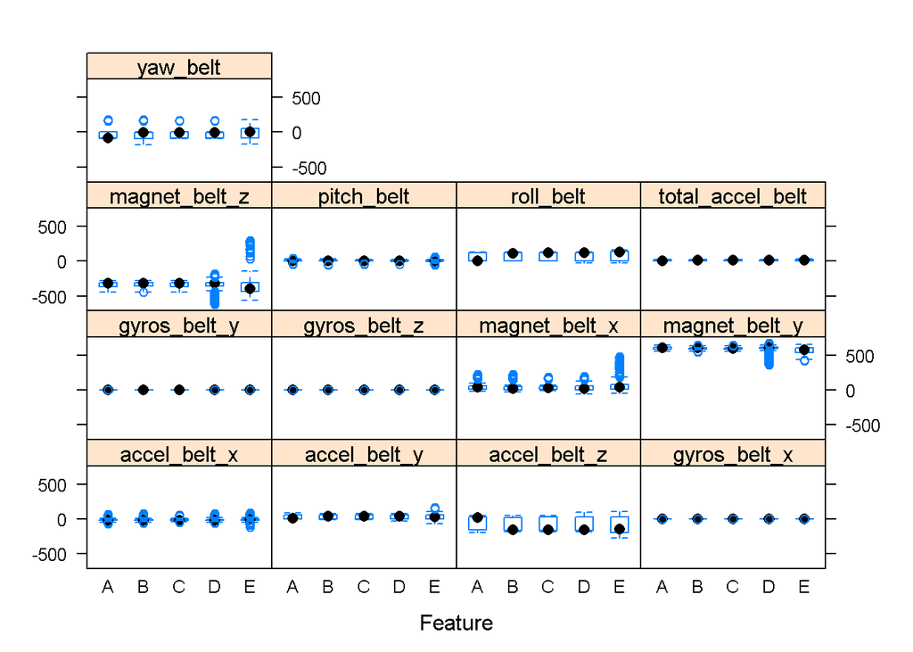

## Density Plot Belt

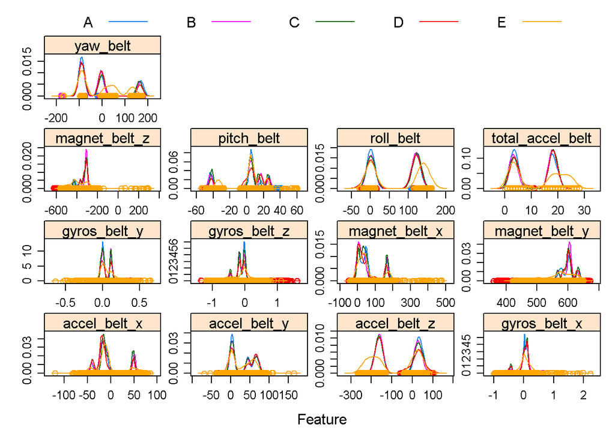

## Box Plot Arm

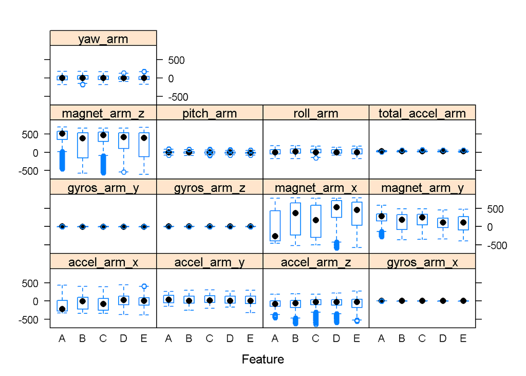

## Density Plot Arm

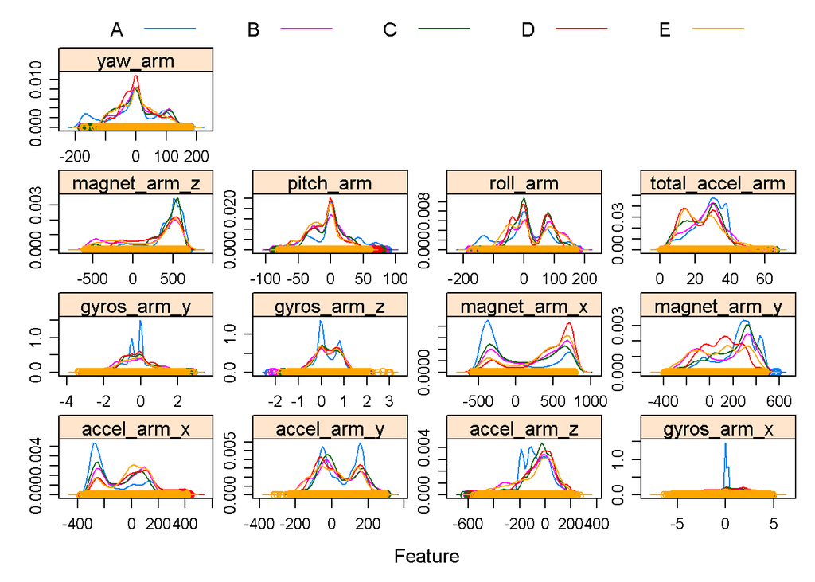

## Box Plot Dumbbell

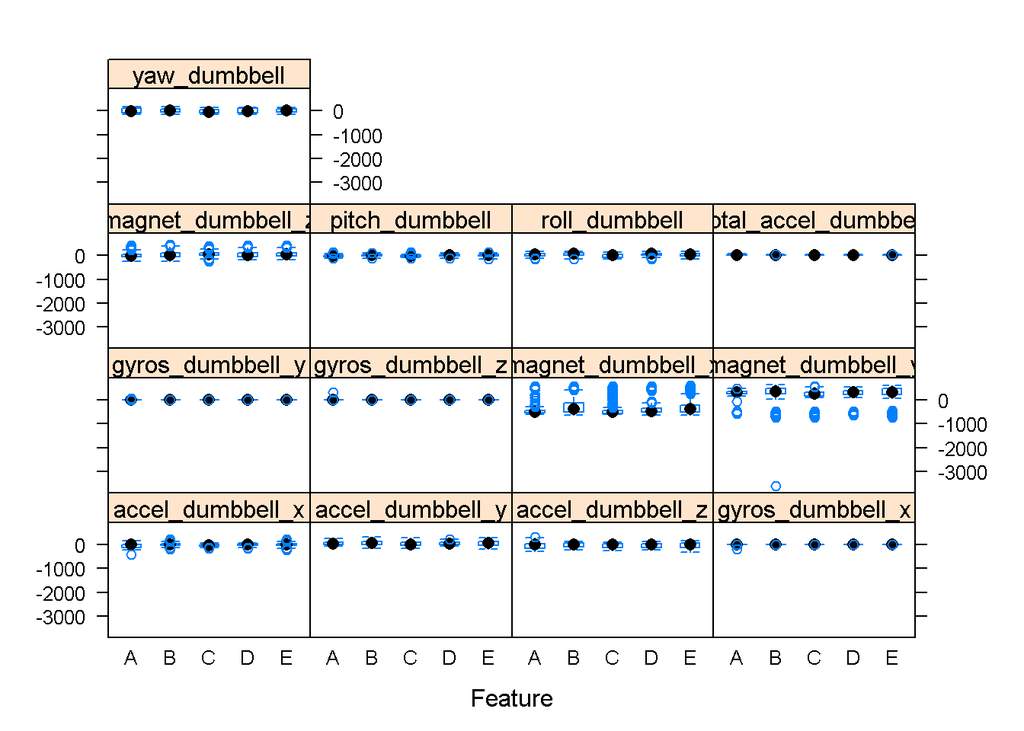

## Density Plot Dumbbell

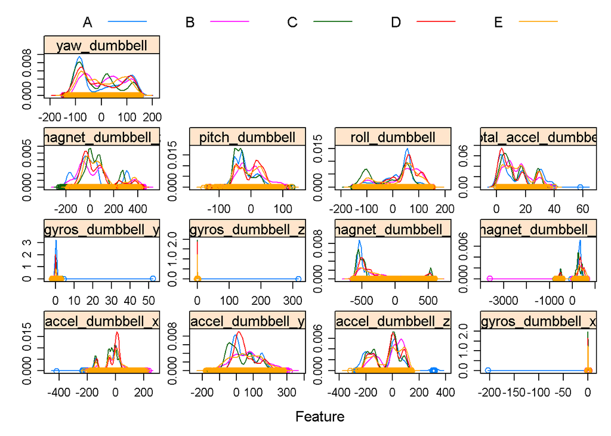

## Box Plot Forearm

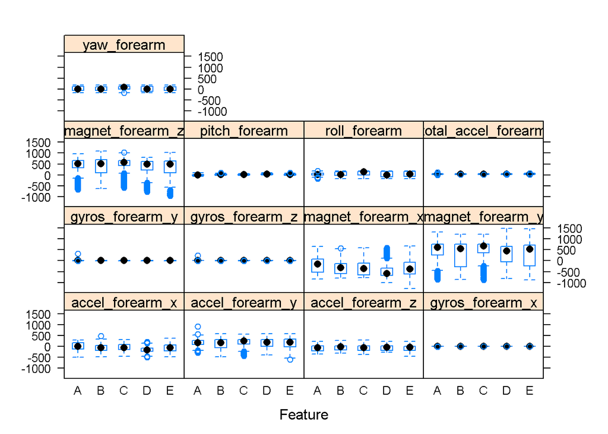

## Density Plot Forearm

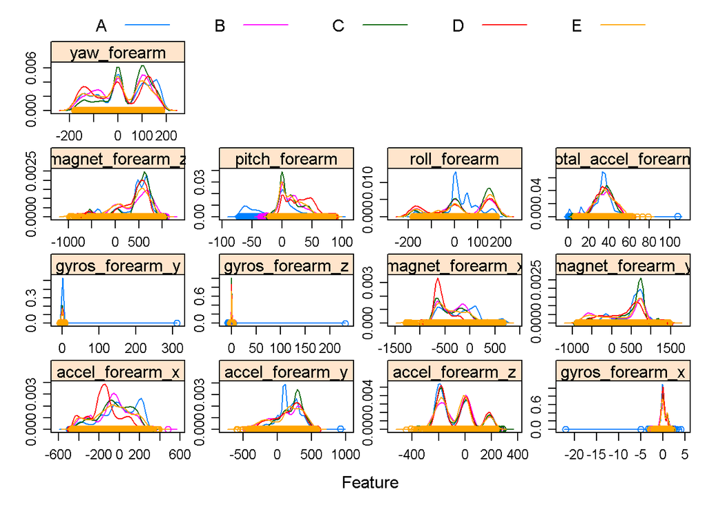